# IGA-677 / Lecture 2: Land, Labor and Serfdom

Yuri M. Zhukov

Visiting Associate Professor of Public Policy

Harvard Kennedy School

September 7, 2023

**Today’s objectives**

1. *Distinguish*: historical varieties of forced labor in Russia
2. *Deduce*: economic and political causes of serfdom
3. *Discuss*: why this institution lasted so long in Russia, and how it intersected with the state’s national security interests

**Why This Topic is Important**

- serfdom has left indelible imprint on Russian economy, institutions
- economic legacy of serfdom:
  - lower household expenditure
  - less urban agglomeration
  - slower industrial development
- institutional legacy of serfdom:
  - collectivization, famine
  - forced labor camps
  - internal passports
- relevance today:
  - *serfdom was a legacy of war*
  - territorial conquest creates “new realities” on the ground
  - adapting to these “new realities” can profoundly transform state and society

[figure not shown]

Serf and Lord

**Varieties of Forced Labor**

1. Slavery (rabstvo)
   - rights:
     - family
     - property
     - mobility
   - usually war prisoners, civilians from conquered territories
   - still exists in some forms today (forced POW labor in WWII)
2. Indentured Service (kholopstvo)
   - rights:
     - family
     - property
     - mobility
   - service by contract, sometimes by inheritance
   - worked in house, not farm
   - abolished by Peter I in 1725

[figure not shown]

Kholopy

**Varieties of Forced Labor**

3. Serfdom (krepostnoye pravo)
   - rights:
     - family
     - property
     - mobility
   - peasants tied to land, kept at/below subsistence level through predatory rents
   - originated in 15th Century, abolished in 1861
   - serfdom also existed in West Europe, but mostly ended there by 16th Century

[figure not shown]

Serfs

# Causes of Serfdom

## Serfdom as a Legacy of War

Between 1263 (start of Grand Duchy) and 1721 (start of Empire), Muscovite Russia **expanded its territory** through war 77 times.

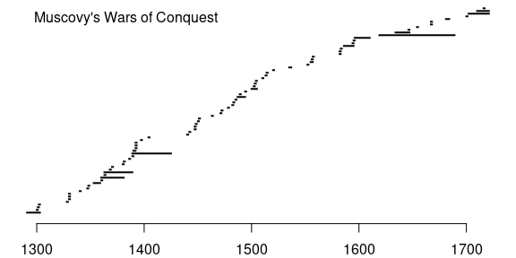

These wars created two problems:

1. abundance of newly conquered land
2. demand for a large army to defend, expand this land

**War Makes the State**

- war demands institutions that are conducive to state formation:  
  - standing army  
  - tax revenues (to support army)  
  - bureaucracy (to raise revenues)
- but Muscovy too underdeveloped to support army through taxes

**Solution**: create *landed army*

- Muscovite army was led by *servitors* (class of warrior nobles)
- in 1400s, state assigns newly conquered lands to servitors
- servitors would be responsible for taxation, military mobilization on these lands

[figure not shown]

Battle for Kazan

**Warriors Become Feudal Lords**

- land assignments initially temporary, then hereditary
- new class of landed nobility born
- initial bargain with peasants:  
  land use in exchange for *rents* (taxes) and/or military service

**Problem**: not enough peasants

- shortage of tenants due to peasant migration to new lands
- fierce competition between landlords drives rents down

**Solution**: serfdom

- state restricts freedom of peasants to move
- peasants enserfed by mid-1600s

[figure not shown]

Peasants Moving

## A Simple Economic Model of Serfdom

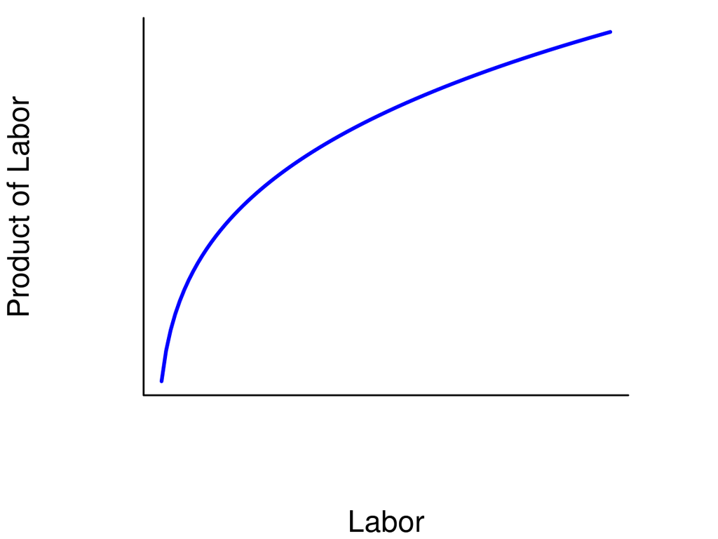

Simple production function, with one factor (**Labor**).  
Declining returns to scale.

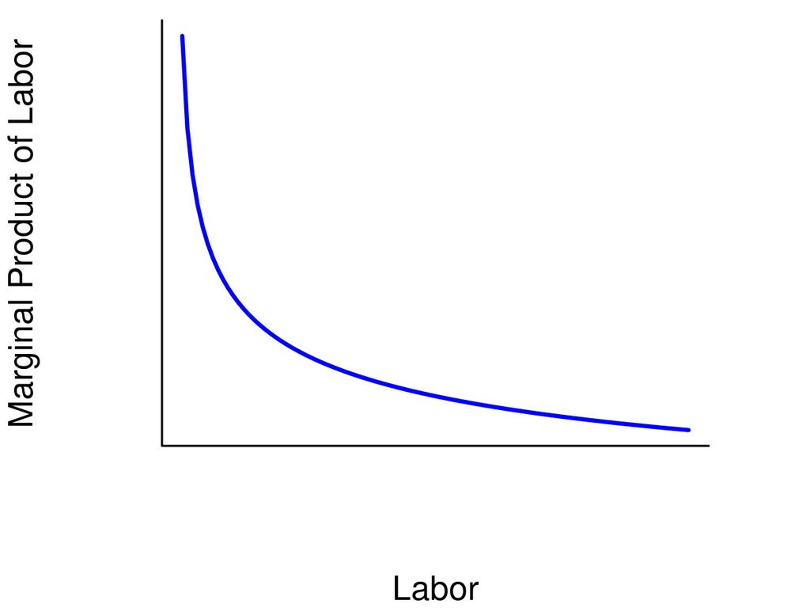

Take the derivative, and we get the **marginal product of labor**.  
This represents how much each additional laborer contributes.

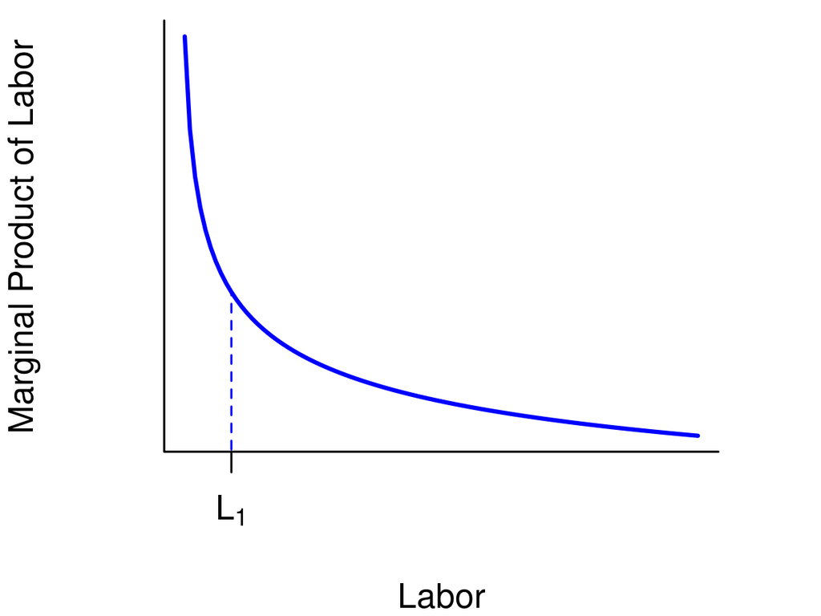

Suppose there are $L_1$ peasants living on this plot of land.  
We’ll assume that labor is scarce, so $L_1$ is pretty small.

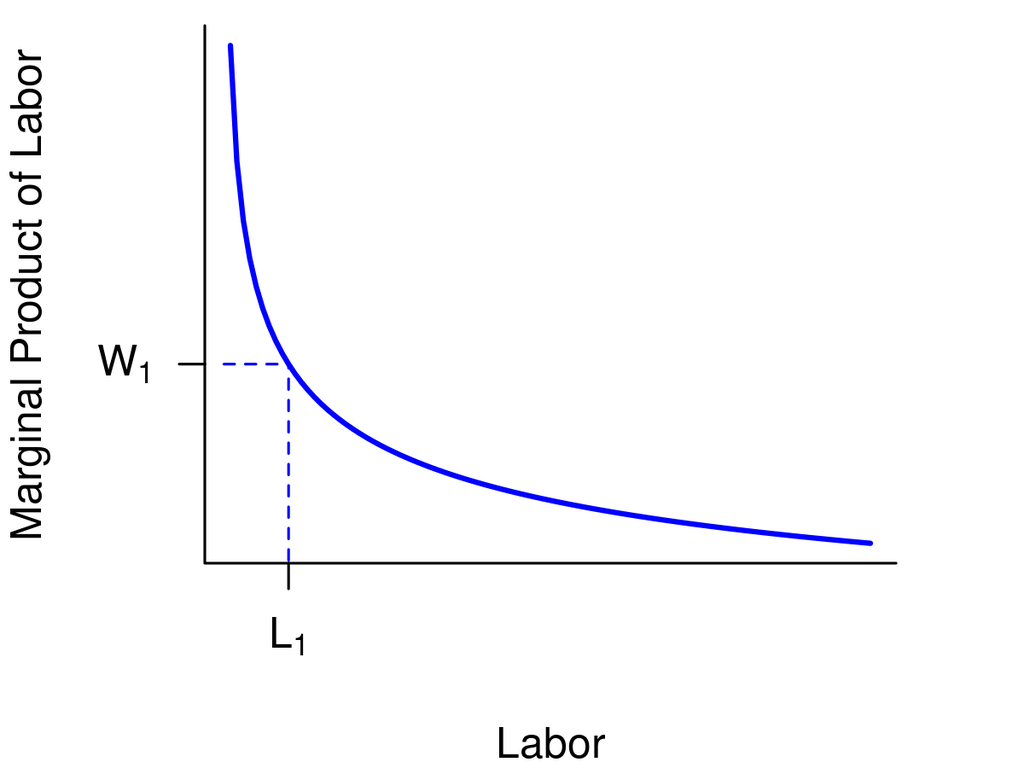

Each of the $L_1$ peasants receives market wage $W_1$.  
This wage depends on the peasant’s contribution to productivity.

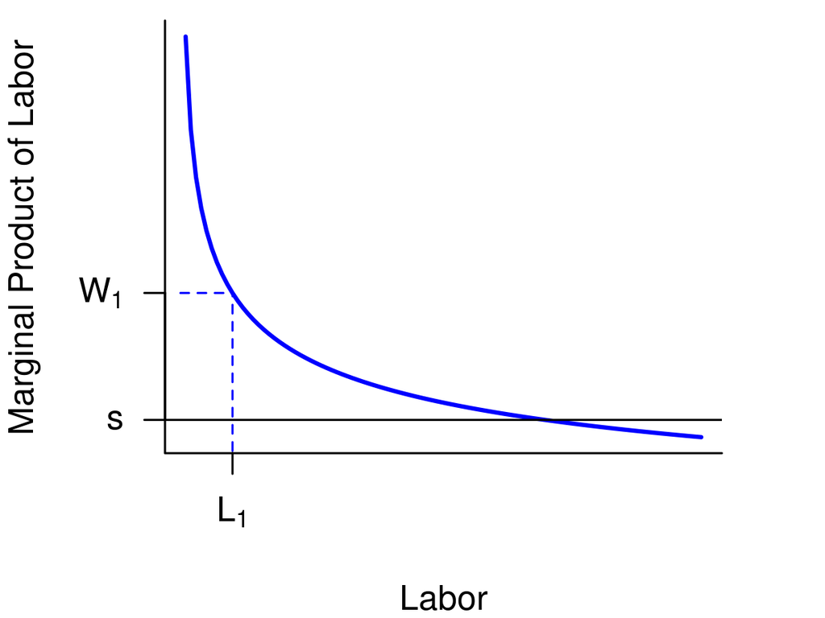

Let $s$ denote level of wages needed for basic subsistence.  
Suppose $W_1$ is above subsistence wage $s$.

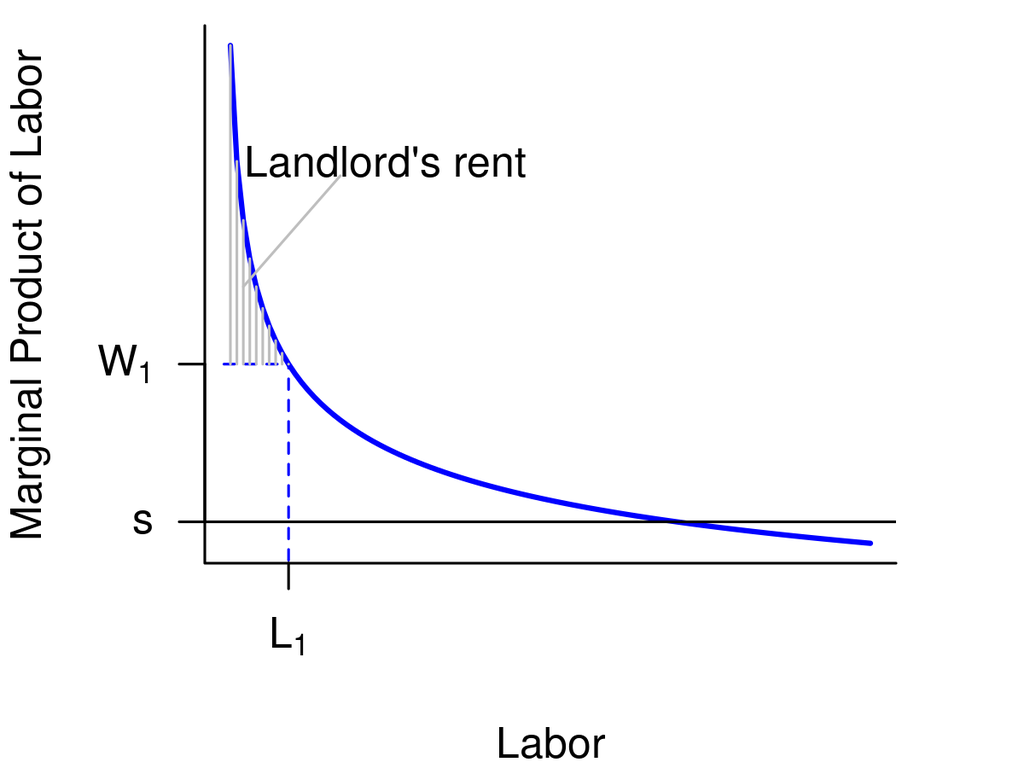

Landlord receives **rent** from the peasants.  
Rent is equivalent to what the peasants produce, minus their wages.

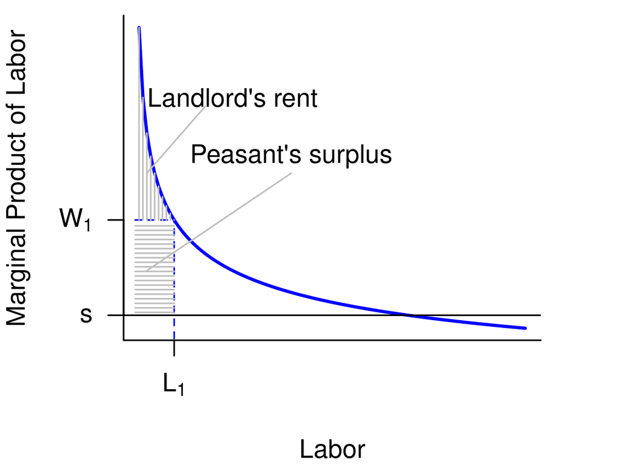

Peasant get to keep the remaining **surplus** (to spend/invest/save).  
Surplus is what they earn, minus what they spend on subsistence.

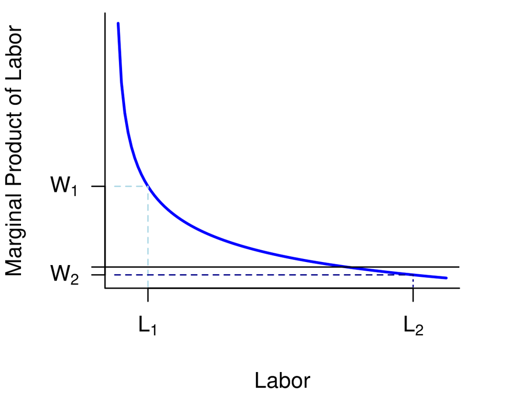

Now suppose there is **population growth**, from $L_1$ to $L_2$.  
Peasants’ market wages fall from $W_1$ to $W_2$, below subsistence!

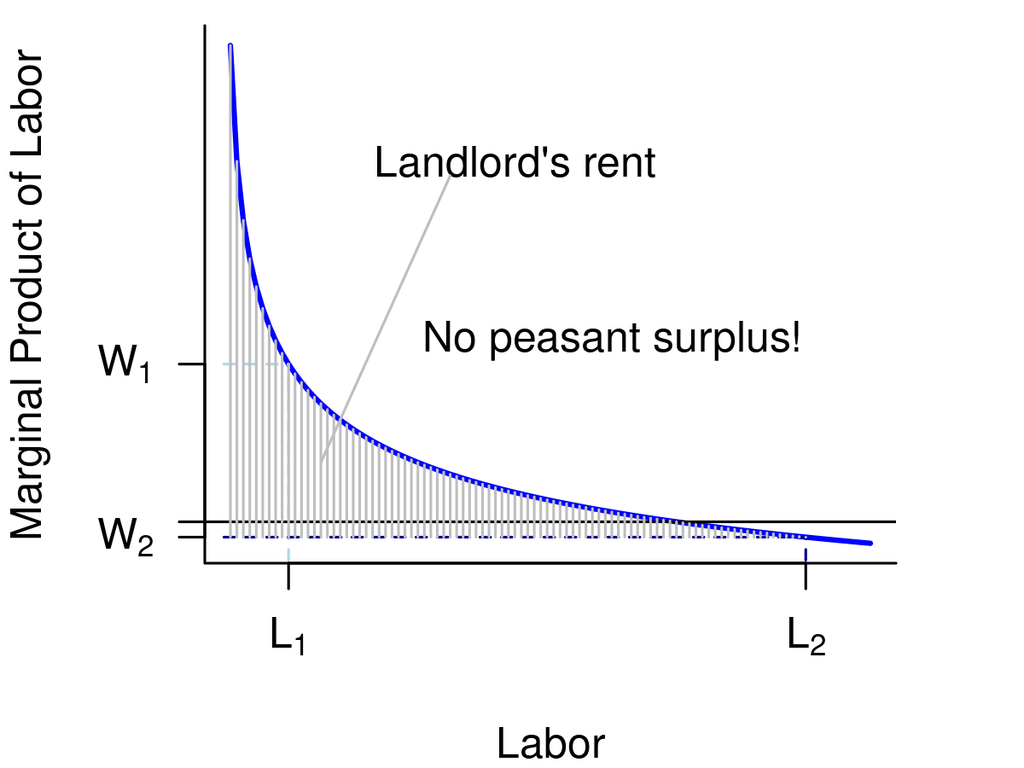

Landlord wins (more tenants $\to$ more rents).  
Peasants lose (lower wages $\to$ less/no surplus).

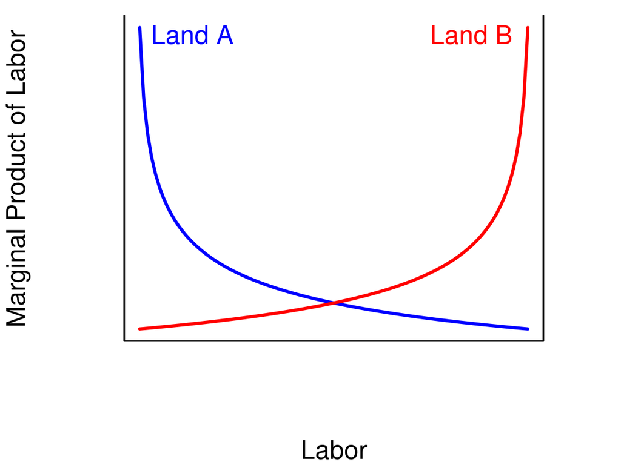

Now suppose a second plot of land opens up (Land B).  
Let’s assume this new land is of equal size and quality as Land A.

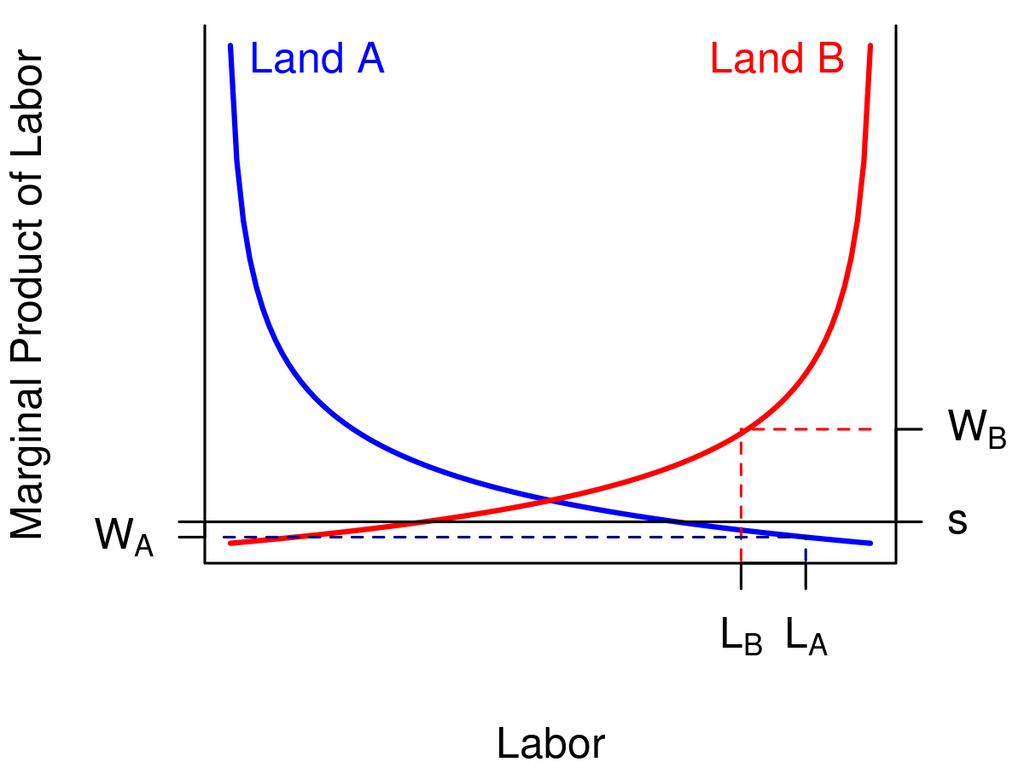

Land A is overpopulated, wages are low.
Land B is underpopulated, wages are high ($L_A$$>$$L_B$, $W_A$$<$$W_B$).

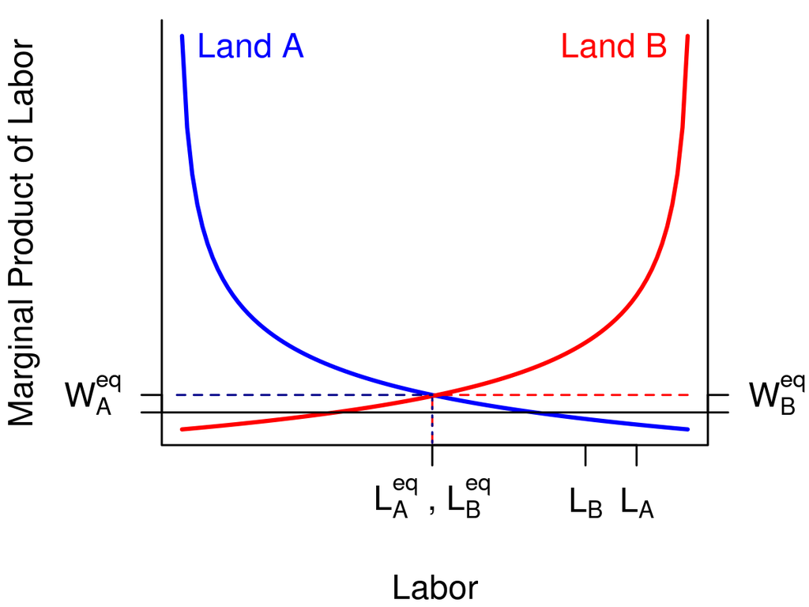

Peasants from Land A begin to migrate to Land B, until population levels reach equilibrium ($L_A^{eq}$, $L_B^{eq}$), wages are same ($W_A^{eq}$$=$$W_B^{eq}$).

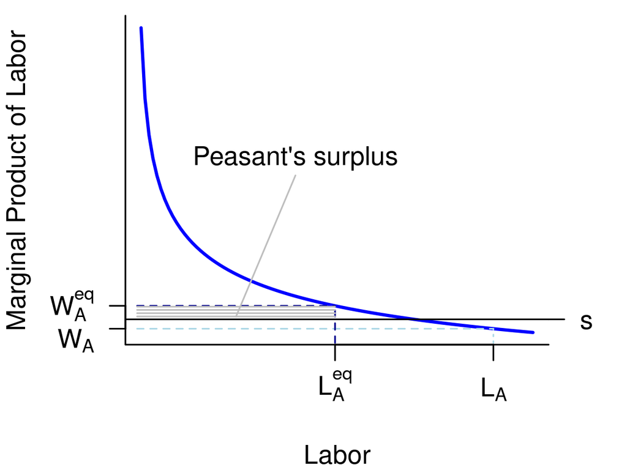

But this is bad for landlord A.  
Out-migration results in fewer tenants and fewer rents.

What are landlord A’s options?  
(a) do nothing, lose money; (b) lobby government to allow **serfdom**.

**Serfdom** $=$  
migration restriction $+$ surplus extraction

# Serfdom and Territorial Expansion

**Land/labor ratio and serfdom**

- serfdom is a political intervention in the market
- *high* land/labor ratio  
  (lots of land, few tenants)
  - market favors tenants
  - wages go up, rents go down
  - serfdom more likely
- *low* land/labor ratio  
  (little land, lots of tenants)
  - market favors landlords
  - wages go down, rents go up
  - serfdom less likely

Why does territorial expansion make serfdom more appealing?

Why not just stop expanding?

[figure not shown]

Serfs

**Russia’s External Threat Environment** (1450-1800)

| Belligerent | Conflicts | Start | End |
| --- | --- | --- | --- |
| Kazan | 3 | 1467 | 1487 |
| Novgorod | 3 | 1471 | 1570 |
| Livonia | 1 | 1477 | 1478 |
| Lithuania | 2 | 1487 | 1503 |
| Sweden | 21 | 1495 | 1742 |
| Crimean Khanate | 2 | 1571 | 1572 |
| Poland | 23 | 1579 | 1794 |
| Cossacks | 26 | 1649 | 1774 |
| Streltsy | 2 | 1682 | 1698 |
| Ottoman Empire | 21 | 1711 | 1791 |
| Finland | 1 | 1714 | 1714 |
| Bashkirs | 1 | 1755 | 1755 |
| Prussia | 10 | 1757 | 1760 |
| Polish Confederates | 1 | 1768 | 1768 |
| France | 9 | 1799 | 1799 |

## End of Serfdom

**Why Did Serfdom Decline?**

- Tsar Alexander II abolished serfdom in 1861
- at the time, 45% of peasants (38% of total pop) were serfs
- but the state had created pathways out of serfdom before:
  - permissions to move on case-by-case basis
  - emancipation after 20 years of military service
  - less enforcement in frontier, newly conquered areas

Why did the state end serfdom?

Were the interests of state and landlords always aligned?

[figure not shown]

Emancipation

## Comparative Perspective

**Meanwhile, in Europe…**

- serfdom ended much earlier (after Black Death)
- landlords didn’t “squeeze peasants” through surplus extraction, mobility restriction
- peasants given property rights
- agricultural revolution in England in 16th Century
- rise of industrialized agriculture
- widespread serfdom/slavery in colonies, but not at home

Why was Russia different? Was it?

Would Muscovy have kept expanding if it never allowed serfdom?

[figure not shown]

England

**NEXT MEETING**

*Colonial Expansion and an Unstable Frontier* (Tu, Sep. 12)

- why Russia got so big
- things to consider:
  - at what point did Russia become a “colonial empire”?
  - what strategies did Russia use to incorporate non-Slavic, non-Christian peoples into its growing empire?